Skip to main content

# Comparing model performances for predicting obesity levels

Author

Anuoluwapo Akinkunmi, Raghav Haralalka, Sebastian Tenorio, Han Bao

Published

November 21, 2026

```python
# import libraries
import os
import numpy as np
import pandas as pd
import requests
import zipfile
import altair as alt
from sklearn import set_config
from sklearn.model_selection import train_test_split
from sklearn.compose import make_column_transformer
from sklearn.preprocessing import StandardScaler, OneHotEncoder, OrdinalEncoder
from sklearn.base import clone
from sklearn.dummy import DummyClassifier
from sklearn.linear_model import LogisticRegression
from sklearn.svm import SVC
from sklearn.pipeline import make_pipeline
from sklearn.model_selection import cross_validate, StratifiedKFold, RandomizedSearchCV
from sklearn.metrics import f1_score, accuracy_score, classification_report
from scipy.stats import loguniform
alt.data_transformers.enable('vegafusion')

# png, so the charts also show in the PDF
_ = alt.renderers.enable("png", scale_factor=2)
```

# 1 Summary

We compared a dummy classifier, logistic regression, and a support vector classifier with a radial basis function kernel (RBF SVC) to predict seven weight-status categories using demographic, family history, and lifestyle features, with height and weight excluded. In five-fold cross-validation, the RBF SVC achieved the highest mean macro F1 score (0.804), followed by logistic regression (0.563) and the dummy classifier (0.041). On the held-out test set, the RBF SVC achieved a macro F1 score of 0.787, compared with 0.041 for the dummy classifier, and correctly classified 498 of 634 records (78.5%). Performance varied across categories. Of the 139 records the model predicted as normal weight, only 67 were labelled normal weight. These results show that the RBF SVC performed best among the models compared on this dataset. Because about 77% of the records are synthetic, its performance on independently collected survey data remains uncertain.

# 2 Introduction

Researchers have used machine learning to classify weight status from information such as eating habits and physical measurements (Kaur et al. 2022; Solomon et al. 2023). Using the University of California, Irvine (UCI) Obesity Levels dataset, Zhang (2025) compared model performance with and without height and weight. In our study, we focus on how well demographic, family history, and lifestyle features predict weight status when those two measurements are excluded.

Our research question is: **How well can demographic, family history, and lifestyle features predict seven weight-status categories when height and weight are excluded, and which classifier performs best?** We compare logistic regression and a support vector classifier with a radial basis function kernel (RBF SVC) against a dummy classifier. This comparison lets us assess whether using the survey features improves predictions over a simple baseline and whether the two fitted models differ in predictive performance.

We use the UCI Obesity Levels dataset (UCI Machine Learning Repository 2019), which contains 2,111 individual-level records based on an online survey conducted in Colombia, Mexico, and Peru. The predictors include demographic characteristics, family history of overweight, and lifestyle factors such as eating habits and physical activity. The response is the recorded weight-status category, ranging from insufficient weight to obesity type III.

# 3 Methods

## 3.1 Data

We used the Estimation of Obesity Levels Based on Eating Habits and Physical Condition dataset from the UCI Machine Learning Repository (UCI Machine Learning Repository 2019; Mendoza Palechor and de la Hoz Manotas 2019), published under the Creative Commons Attribution 4.0 International (CC BY 4.0) license. The code below downloads the original archive into data/raw/, extracts the data file, and removes the archive. The download is skipped if the data file already exists, allowing the report to be re-rendered without downloading it again. Each row represents an individual’s survey responses on demographics, family history, eating habits, and physical condition, along with a weight-status category; approximately 77% of the records are synthetic, generated by the authors to balance the classes. The dataset contains no missing values, so no rows were removed or imputed. Since the authors assigned weight-status categories based on BMI calculated from height and weight, we removed both variables to prevent data leakage and ensure models learn from survey and lifestyle information rather than directly recovering the label from its definition. We then split the data into stratified training (70%) and test (30%) sets using a fixed random seed to preserve class proportions and ensure reproducibility. Both sets were saved to data/processed/. All exploratory analysis, preprocessing, and model selection were performed using only the training set, reserving the test set for final evaluation.

```python
# Create the data folders if they don't exist
os.makedirs("../data/raw", exist_ok=True)
os.makedirs("../data/processed", exist_ok=True)

csv_path = "../data/raw/ObesityDataSet_raw_and_data_sinthetic.csv"

# Download data as zip and extract
# This archive (UCI "Estimation of Obesity Levels Based On Eating Habits and Physical Condition") also contains ObesityDataSet_raw_and_data_sinthetic.csv
if not os.path.exists(csv_path):
    url = (
        "https://archive.ics.uci.edu/static/public/544/"
        "estimation+of+obesity+levels+based+on+eating+habits+"
        "and+physical+condition.zip"
    )
    zip_path = "../data/raw/obesity_levels.zip"

    response = requests.get(url)
    response.raise_for_status()
    with open(zip_path, "wb") as f:
        f.write(response.content)

    with zipfile.ZipFile(zip_path, "r") as zip_ref:
        zip_ref.extractall("../data/raw")

    os.remove(zip_path)

# Read in data
obesity = pd.read_csv(csv_path).drop(columns=["Height","Weight"])
```

```python
# Do the train/test split and save the results to data/processed/
set_config(transform_output="pandas")

# split the data into training (70%) and test (30%) sets
obesity_train, obesity_test = train_test_split(
    obesity, train_size=0.70, stratify=obesity["NObeyesdad"], random_state=522
)

obesity_train.to_csv("../data/processed/obesity_train.csv", index=False)
obesity_test.to_csv("../data/processed/obesity_test.csv", index=False)
```

## 3.2 Exploratory data analysis

This section describes how we explored the training data. We first summarized the numeric features in the training set (Table 1), checked the balance of the seven weight-status categories (Figure 1), and compared the distribution of each feature across categories (Figure 2 and Figure 3).

```python
obesity_train.describe().T.round(2)
```

Table 1: Summary statistics of the numeric features in the training set.

|  | count | mean | std | min | 25% | 50% | 75% | max |
| --- | --- | --- | --- | --- | --- | --- | --- | --- |
| Age | 1477.0 | 24.46 | 6.46 | 15.0 | 20.00 | 22.91 | 26.00 | 61.0 |
| FCVC | 1477.0 | 2.43 | 0.54 | 1.0 | 2.00 | 2.43 | 3.00 | 3.0 |
| NCP | 1477.0 | 2.68 | 0.79 | 1.0 | 2.64 | 3.00 | 3.00 | 4.0 |
| CH2O | 1477.0 | 1.99 | 0.61 | 1.0 | 1.54 | 2.00 | 2.44 | 3.0 |
| FAF | 1477.0 | 1.00 | 0.85 | 0.0 | 0.11 | 1.00 | 1.63 | 3.0 |
| TUE | 1477.0 | 0.64 | 0.61 | 0.0 | 0.00 | 0.58 | 1.00 | 2.0 |

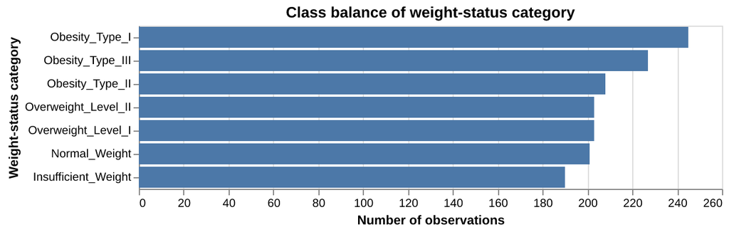

Figure 1: Number of training-set observations in each weight-status category.

```python
class_order = [
    "Insufficient_Weight", "Normal_Weight",
    "Overweight_Level_I", "Overweight_Level_II",
    "Obesity_Type_I", "Obesity_Type_II", "Obesity_Type_III",
]

alt.Chart(obesity_train).mark_bar().encode(
    x=alt.X("count():Q", title="Number of observations"),
    y=alt.Y("NObeyesdad:N",sort = "-x", title="Weight-status category"),
).properties(width=500,
    title=alt.TitleParams(
    "Class balance of weight-status category",
    anchor="middle",
    )
)
```

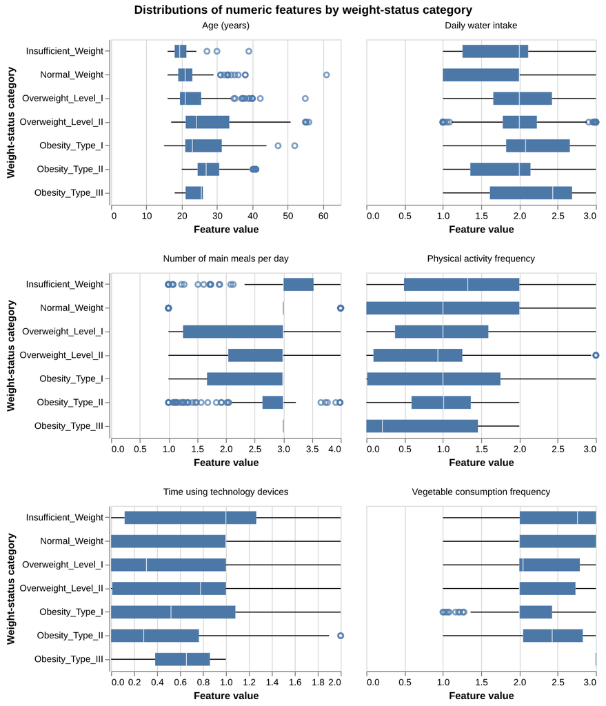

Figure 2: Distributions of the numeric features in the training set by weight-status category.

```python
feature_labels = {
    "Age": "Age (years)",
    "FCVC": "Vegetable consumption frequency",
    "NCP": "Number of main meals per day",
    "CH2O": "Daily water intake",
    "FAF": "Physical activity frequency",
    "TUE": "Time using technology devices",
}

# melt for plotting via facets
obesity_train_melted = obesity_train.melt(
    id_vars=["NObeyesdad"],
    value_vars=list(feature_labels.keys()),
    var_name="feature",
    value_name="value",
)
obesity_train_melted["feature"] = obesity_train_melted["feature"].map(feature_labels)

alt.Chart(obesity_train_melted, width=250, height=180).mark_boxplot().encode(
    x=alt.X("value:Q", title="Feature value"),
    y=alt.Y("NObeyesdad:N", sort=class_order, title="Weight-status category"),
).facet(
    facet=alt.Facet("feature:N", title = None),
    columns=2,
).resolve_scale(
    x="independent"
).properties(
    title=alt.TitleParams(
    "Distributions of numeric features by weight-status category",
    anchor="middle"
    )
)
```

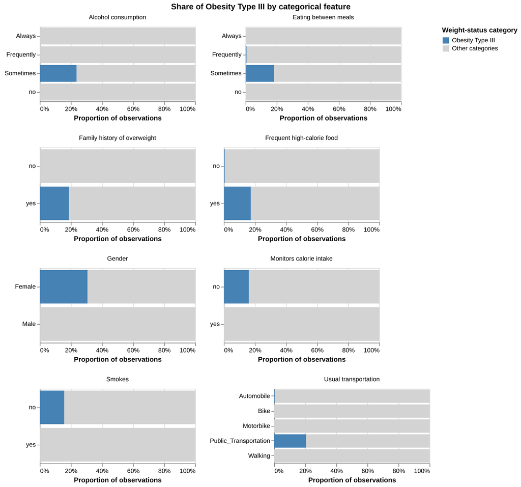

Figure 3: Proportion of training-set observations classified as Obesity Type III within each level of the categorical features. All other weight-status categories are shown in grey.

```python
cat_labels = {
    "Gender": "Gender",
    "family_history_with_overweight": "Family history of overweight",
    "FAVC": "Frequent high-calorie food",
    "CAEC": "Eating between meals",
    "SMOKE": "Smokes",
    "SCC": "Monitors calorie intake",
    "CALC": "Alcohol consumption",
    "MTRANS": "Usual transportation",
}

obesity_train_cat = obesity_train.melt(
    id_vars=["NObeyesdad"],
    value_vars=list(cat_labels.keys()),
    var_name="feature",
    value_name="level",
)
obesity_train_cat["feature"] = obesity_train_cat["feature"].map(cat_labels)

focus_class = "Obesity_Type_III"
focus_label = "Obesity Type III"

alt.Chart(obesity_train_cat, width=250, height=120).transform_calculate(
    group=f"datum.NObeyesdad == '{focus_class}' ? '{focus_label}' : 'Other categories'",
    group_order=f"datum.NObeyesdad == '{focus_class}' ? 0 : 1",
).mark_bar().encode(
    y=alt.Y("level:N", title=None),
    x=alt.X(
        "count():Q",
        stack="normalize",
        title="Proportion of observations",
        axis=alt.Axis(format="%"),
    ),
    color=alt.Color(
        "group:N",
        scale=alt.Scale(
            domain=[focus_label, "Other categories"],
            range=["steelblue", "lightgray"],
        ),
        title="Weight-status category",
    ),
    order=alt.Order("group_order:Q"),
).facet(
    facet=alt.Facet("feature:N", title=None),
    columns=2,
).resolve_scale(
    y="independent"
).resolve_axis(
    x="independent"
).properties(
    title=alt.TitleParams(
        f"Share of {focus_label} by categorical feature",
        anchor="middle",
    )
)
```

Exploratory data analysis shows that age, physical activity frequency, gender and family history of overweight vary most across weight-status categories, while most other features overlap considerably between categories. The seven categories are roughly balanced. Obesity Type III stands out as almost all of these observations are female, report a family history of overweight and give the same answers on several survey questions, which likely reflects the synthetic records in the data set and may make this category unusually easy to predict.

## 3.3 Analysis

This section describes how we prepared the features for modelling and compared the classifiers. We first describe the preprocessing applied to each type of feature, then define the three models, explain our choice of evaluation metric, and describe how cross-validation was used to tune and compare the models before evaluating the selected model once on the held-out test set.

The analysis was carried out using the Python programming language (Van Rossum and Drake 2009) and the packages requests (Reitz 2011), NumPy (Harris et al. 2020), pandas (McKinney 2010), Altair (VanderPlas et al. 2018) and scikit-learn (Pedregosa et al. 2011). Parts of the code used to perform the analysis and create this report were adapted from https://github.com/UBC-MDS/DSCI_522_project-template-breast-cancer-predictor.

### 3.3.1 Preprocessing

Before modelling, we prepared the features so that all three classifiers could use them. The numeric features (age, vegetable consumption frequency, number of main meals, daily water intake, physical activity frequency, and time spent using technology devices) were standardized to have a mean of zero and a standard deviation of one, because logistic regression and support vector classifiers are sensitive to the scale of their inputs. Several of these features were originally recorded on short integer scales, but most values in the dataset are not whole numbers because of the synthetic records, so we treated them as continuous rather than categorical. The binary features (gender, family history of overweight, frequent consumption of high-calorie food, smoking, and calorie monitoring) were each converted to a single 0/1 indicator. Eating between meals and alcohol consumption were ordinal encoded from least to most frequent (“no”, “sometimes”, “frequently”, “always”) to preserve their natural order, and the usual mode of transportation was one-hot encoded because its categories have no order, ignoring any category not seen during training. All preprocessing steps were combined with each model in a pipeline, so that they were learned only from the training data within each cross-validation fold and no information from the test data influenced the preprocessing.

```python
# Preprocessing plan: standardize numeric features, one-hot encode binary and categorical features, and ordinal encode the two frequency features. The frequency features are ordered from least to most frequent.

# Reading the saved training and testing dataset files if dataframes not in memory
if "obesity_train" not in globals() or "obesity_test" not in globals():
    obesity_train = pd.read_csv("../data/processed/obesity_train.csv")
    obesity_test = pd.read_csv("../data/processed/obesity_test.csv")

# Group features by how they should be transformed
numeric_features = ["Age", "FCVC", "NCP", "CH2O", "FAF", "TUE"]
binary_features = ["Gender", "family_history_with_overweight", "FAVC", "SMOKE", "SCC"]
ordinal_features = ["CAEC", "CALC"]
categorical_features = ["MTRANS"]

# Order of the frequency categories (least to most)
frequency_levels = ["no", "Sometimes", "Frequently", "Always"]

# Make a column transformer that applies the appropriate transformation to each group of features. The remainder="passthrough" argument means that any features not listed in the groups will be passed through unchanged.
obesity_preprocessor = make_column_transformer(
    (StandardScaler(), numeric_features),
    (OneHotEncoder(drop="if_binary", dtype=int, sparse_output=False), binary_features),
    (OrdinalEncoder(categories=[frequency_levels, frequency_levels]), ordinal_features),
    (OneHotEncoder(handle_unknown="ignore", sparse_output=False), categorical_features),
    remainder="passthrough"
)

# Fit on training data only, then transform both training and test data and save the results
obesity_preprocessor.fit(obesity_train)
scaled_obesity_train = obesity_preprocessor.transform(obesity_train)
scaled_obesity_test = obesity_preprocessor.transform(obesity_test)

scaled_obesity_train.to_csv("../data/processed/processed_obesity_train.csv", index=False)
scaled_obesity_test.to_csv("../data/processed/processed_obesity_test.csv", index=False)
```

## 3.4 Model Selection

### 3.4.1 Defining the models

We compare three classifiers. The **Dummy Classifier** always predicts the most frequent class and serves as our baseline. **Logistic Regressor** model is a fast and interpretable linear model, while the **RBF Support Vector Classifier (SVC)** can learn non-linear decision boundaries. Every model is placed in a pipeline with the preprocessor defined above, so that during cross-validation the preprocessing is fitted only on the training folds and no information from the validation folds leaks into the encodings.

```python
# Splitting the features and target
X_train = obesity_train.drop(columns="NObeyesdad")
y_train = obesity_train["NObeyesdad"]
X_test = obesity_test.drop(columns="NObeyesdad")
y_test = obesity_test["NObeyesdad"]

# Defining the models
models = {
    "Dummy": DummyClassifier(random_state=522),
    "Logistic Regression": LogisticRegression(max_iter=2000, random_state=522),
    "RBF SVC": SVC(random_state=522),
}

# clone() gives each pipeline its own unfitted copy of the preprocessor
pipelines = {
    name: make_pipeline(clone(obesity_preprocessor), model)
    for name, model in models.items()
}
```

### 3.4.2 Evaluation Metric

We select models using the **macro-averaged F1 score**. The F1 score combines precision and recall for a single class, and the macro average weights all seven weight-status classes equally, so a model that performs poorly on any one class is penalized. We also report accuracy as a more familiar secondary measure, but all model selection decisions use macro F1 only. Table 2 shows the training class proportions, which range from 12.9% to 16.6%. The classes are close to balanced, so accuracy is not dominated by any single class, but macro F1 can still reveal weaknesses on individual classes that accuracy would hide.

```python
SCORING = {"f1_macro": "f1_macro", "accuracy": "accuracy"}  # selection uses f1_macro

# Same shuffled, stratified folds for every model
cv = StratifiedKFold(n_splits=5, shuffle=True, random_state=522)

y_train.value_counts(normalize=True).round(3).rename("proportion").to_frame()
```

Table 2: Proportion of each weight-status class in the training set.

| NObeyesdad | proportion |
| --- | --- |
| Obesity_Type_I | 0.166 |
| Obesity_Type_III | 0.154 |
| Obesity_Type_II | 0.141 |
| Overweight_Level_II | 0.137 |
| Overweight_Level_I | 0.137 |
| Normal_Weight | 0.136 |
| Insufficient_Weight | 0.129 |

### 3.4.3 Cross Validation and Hyperparameter Tuning

All model comparisons use five-fold stratified cross-validation on the training set only. The dummy classifier has no hyperparameters to tune, so we cross-validate it directly. For logistic regression and the support vector classifier, we use a randomized hyperparameter search with 20 sampled candidates each, scored by validation macro F1. Both models’ regularization strength (C) and the support vector classifier’s kernel width (gamma) can matter across several orders of magnitude, so we sample them from log-uniform distributions. Random search covers this continuous range at a fixed cost and avoids committing to a coarse grid of values. Once each search is complete, its best candidate is refitted on the whole training set. The test set is not used at this stage.

```python
CV_KWARGS = dict(cv=cv, scoring=SCORING, return_train_score=True)

# Baseline: cross-validated directly
dummy_cv = cross_validate(
    pipelines["Dummy"], X_train, y_train,
    **CV_KWARGS
)

# Search spaces (pipeline step name + "__" + parameter name)
param_dists = {
    "Logistic Regression": {"logisticregression__C": loguniform(1e-3, 1e2)},
    "RBF SVC": {
        "svc__C": loguniform(1e-2, 1e3),
        "svc__gamma": loguniform(1e-3, 1e1),
    },
}

searches = {}
for name, dist in param_dists.items():
    searches[name] = RandomizedSearchCV(
        pipelines[name], dist,
        n_iter=20, refit="f1_macro", random_state=522,
        **CV_KWARGS
    )
    searches[name].fit(X_train, y_train)
```

# 4 Results

## 4.1 Model Comparison

Table 3 shows the cross-validation results for the dummy baseline and the best configuration found for each tuned model. “Validation” scores come from held-out folds inside the training set. They are not the final test scores.

```python
rows = {
    "Dummy": {
        "Validation macro F1 (mean)": dummy_cv["test_f1_macro"].mean(),
        "Validation macro F1 (SD)": dummy_cv["test_f1_macro"].std(),
        "Training macro F1 (mean)": dummy_cv["train_f1_macro"].mean(),
        "Validation accuracy (mean)": dummy_cv["test_accuracy"].mean(),
        "Best hyperparameters": "none",
    }
}
for name, s in searches.items():
    i, r = s.best_index_, s.cv_results_
    rows[name] = {
        "Validation macro F1 (mean)": r["mean_test_f1_macro"][i],
        "Validation macro F1 (SD)": r["std_test_f1_macro"][i],
        "Training macro F1 (mean)": r["mean_train_f1_macro"][i],
        "Validation accuracy (mean)": r["mean_test_accuracy"][i],
        "Best hyperparameters": str(
            {k.split("__")[-1]: float(f"{v:.3g}") for k, v in s.best_params_.items()}
        ),
    }

comparison = pd.DataFrame(rows).T
comparison.round(4)
```

Table 3: Five-fold cross-validation results on the training set (mean and standard deviation across folds).

|  | Validation macro F1 (mean) | Validation macro F1 (SD) | Training macro F1 (mean) | Validation accuracy (mean) | Best hyperparameters |
| --- | --- | --- | --- | --- | --- |
| Dummy | 0.04065 | 0.000058 | 0.04065 | 0.165877 | none |
| Logistic Regression | 0.563001 | 0.023884 | 0.597163 | 0.586328 | {'C': 34.6} |
| RBF SVC | 0.803639 | 0.014202 | 1.0 | 0.798914 | {'C': 34.1, 'gamma': 0.853} |

The dummy baseline reaches a validation macro F1 of only 0.041, so the survey responses carry predictive information beyond the class frequencies. The support vector classifier clearly outperforms logistic regression, with a mean validation macro F1 of 0.804 compared with 0.563. This difference of 0.241 is more than ten times the fold standard deviation of either model (0.014 for the support vector classifier and 0.024 for logistic regression), so the gap cannot be explained by fold-to-fold variation. Validation accuracy shows the same ordering.

The training scores help explain this difference. Logistic regression’s training macro F1 (0.597) is close to its validation score, which suggests that a linear model cannot capture the structure in these features. The support vector classifier, on the other hand, fits the training data almost perfectly (training macro F1 of 1.000), so it overfits to some degree. Even so, it generalizes much better to the validation folds than logistic regression does.

## 4.2 Selected Model

We select the tuned model with the highest mean validation macro F1. The dummy is excluded because it is only a baseline.

```python
best_name = max(searches, key=lambda n: searches[n].best_score_)
best_search = searches[best_name]
i = best_search.best_index_

best_cv_f1 = best_search.best_score_
best_cv_sd = best_search.cv_results_["std_test_f1_macro"][i]
best_train_f1 = best_search.cv_results_["mean_train_f1_macro"][i]
best_params = {k.split("__")[-1]: float(f"{v:.3g}") for k, v in best_search.best_params_.items()}
dummy_f1 = dummy_cv["test_f1_macro"].mean()

print(best_name, best_params)
```

```
RBF SVC {'C': 34.1, 'gamma': 0.853}
```

The selected model is **RBF SVC**, with a mean validation macro F1 of 0.804 (SD 0.014 across folds) against 0.041 for the dummy baseline. Its training macro F1 is 1.000, so the gap between training and validation scores is 0.196. The selected hyperparameters are {‘C’: 34.1, ‘gamma’: 0.853}.

## 4.3 Fit and Test

Having chosen the model and its hyperparameters using training data only, we fit this pipeline once on the full training set and evaluate it once on the held-out test set. The test results were not used to change any modelling choice.

```python
# Final fit: best pipeline + best hyperparameters, fitted on all training data
final_model = clone(pipelines[best_name]).set_params(**best_search.best_params_)
final_model.fit(X_train, y_train)

# One-time evaluation on the held-out test set
y_pred = final_model.predict(X_test)
test_f1 = f1_score(y_test, y_pred, average="macro")
test_acc = accuracy_score(y_test, y_pred)

# Baseline on the same test set, for context only (not used for selection)
dummy_test_f1 = f1_score(
    y_test, clone(pipelines["Dummy"]).fit(X_train, y_train).predict(X_test), average="macro"
)

print(f"{best_name}: test macro F1 = {test_f1:.3f}, test accuracy = {test_acc:.3f}")
```

```
RBF SVC: test macro F1 = 0.787, test accuracy = 0.785
```

## 4.4 Final Results

On the test set, the final **RBF SVC** model achieves a macro F1 of **0.787** and an accuracy of 0.785, compared with a macro F1 of 0.041 for the dummy baseline. This is close to the cross-validated estimate of 0.804, a difference of -0.016. Table 4 gives per-class performance, and Figure 4 shows which classes are confused.

```python
order = ["Insufficient_Weight", "Normal_Weight", "Overweight_Level_I",
         "Overweight_Level_II", "Obesity_Type_I", "Obesity_Type_II", "Obesity_Type_III"]

report = pd.DataFrame(
    classification_report(y_test, y_pred, labels=order, output_dict=True, zero_division=0)
).T
report.loc[order + ["macro avg"], ["precision", "recall", "f1-score", "support"]].round(3)
```

Table 4: Per-class precision, recall and F1 on the held-out test set.

|  | precision | recall | f1-score | support |
| --- | --- | --- | --- | --- |
| Insufficient_Weight | 0.897 | 0.744 | 0.813 | 82.0 |
| Normal_Weight | 0.482 | 0.779 | 0.596 | 86.0 |
| Overweight_Level_I | 0.823 | 0.586 | 0.685 | 87.0 |
| Overweight_Level_II | 0.764 | 0.632 | 0.692 | 87.0 |
| Obesity_Type_I | 0.775 | 0.811 | 0.793 | 106.0 |
| Obesity_Type_II | 0.965 | 0.921 | 0.943 | 89.0 |
| Obesity_Type_III | 0.990 | 0.990 | 0.990 | 97.0 |
| macro avg | 0.814 | 0.781 | 0.787 | 634.0 |

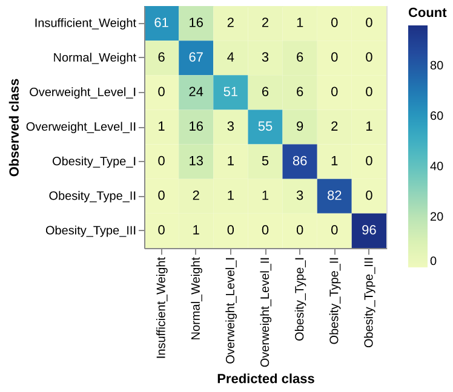

Figure 4: Confusion matrix on the held-out test set. Rows are observed classes and columns are predicted classes, ordered from lowest to highest weight status.

```python
cm = pd.crosstab(y_test, y_pred, rownames=["observed"], colnames=["predicted"]).reindex(
    index=order, columns=order, fill_value=0
)
cm_long = cm.reset_index().melt(id_vars="observed", var_name="predicted", value_name="count")

base = alt.Chart(cm_long).encode(
    x=alt.X("predicted:N", sort=order, title="Predicted class"),
    y=alt.Y("observed:N", sort=order, title="Observed class"),
)
heatmap = base.mark_rect().encode(color=alt.Color("count:Q", title="Count"))
labels = base.mark_text().encode(
    text="count:Q",
    color=alt.condition(alt.datum.count > cm.values.max() / 2, alt.value("white"), alt.value("black")),
)
(heatmap + labels).properties(width=200, height=200)
```

The most frequent errors involve the normal weight class, which has an F1 of 0.596 (Table 4). Its recall is 0.779, but its precision is only 0.482: the model predicted normal weight for 139 test observations, and only 67 of them were truly normal weight. Many of the other classes’ errors fall into this category (Figure 4), including 24 overweight level I, 16 insufficient weight, 16 overweight level II, 13 obesity type I observations. The two overweight classes also score lower (F1 of 0.685 and 0.692). Most errors are between neighbouring categories, although some observations skip categories. In contrast, obesity types II and III are rarely confused with other classes (F1 of 0.943 and 0.990). This is plausible because the labels were defined from body mass index, which our models cannot see (height and weight were excluded), so people near a category boundary can have very similar survey responses.

Because about 77% of the records in this dataset are synthetic (Mendoza Palechor and de la Hoz Manotas, 2019), these scores may be optimistic compared with performance on independently collected survey data.

# 5 Discussion

We found that survey information about age, family history, and lifestyle helped predict the seven weight-status categories even without height and weight. In five-fold cross-validation, the mean macro F1 scores were 0.804 for the RBF SVC, 0.563 for logistic regression, and 0.041 for the dummy classifier (Table 3). On the held-out test set, the selected RBF SVC achieved a macro F1 score of 0.787, compared with 0.041 for the dummy classifier.

The model had more difficulty with some categories than others. It predicted normal weight for 139 records, but only 67 of those records were in that category. Its most common mistake was to classify people in overweight level I as normal weight (Figure 4). It did much better on obesity type III, correctly classifying 96 of 97 records. We expected this category to be easier to identify because many of its records had similar survey answers in the training data. If the same mistakes occur in new surveys, researchers could use them to decide what additional information to collect.

About 77% of the dataset consists of synthetic records (Mendoza Palechor and de la Hoz Manotas 2019). The training and test sets both came from this dataset, and we only used one train–test split. The model may perform differently on a new set of survey responses. To apply these findings to another survey, we would expect people to understand the questions in similar ways and the survey to use the same body mass index (BMI)-based weight categories.

A next step would be to test the model on new survey data. We could check whether it still predicts obesity type III well and whether it still predicts normal weight too often. We could also compare records the model got right and wrong to see what information might help it tell similar categories apart.

# 6 References

“Estimation of Obesity Levels Based on Eating Habits and Physical Condition.” 2019. UCI Machine Learning Repository. https://doi.org/10.24432/C5H31Z.

Kaur, Rajdeep, Rakesh Kumar, and Meenu Gupta. 2022. “Predicting Risk of Obesity and Meal Planning to Reduce the Obese in Adulthood Using Artificial Intelligence.” *Endocrine* 78 (3): 458–469. https://doi.org/10.1007/s12020-022-03215-4.

Mendoza Palechor, Fabio, and Alexis de la Hoz Manotas. 2019. “Dataset for Estimation of Obesity Levels Based on Eating Habits and Physical Condition in Individuals from Colombia, Peru and Mexico.” *Data in Brief* 25: 104344. https://doi.org/10.1016/j.dib.2019.104344.

Solomon, Dahlak Daniel, Shakir Khan, Sonia Garg, et al. 2023. “Hybrid Majority Voting: Prediction and Classification Model for Obesity.” *Diagnostics* 13 (15): 2610. https://doi.org/10.3390/diagnostics13152610.

Zhang, Junyuan. 2025. “Machine Learning Analysis of Obesity Levels Based on Lifestyle and Physical Features.” *Theoretical and Natural Science* 135: 90–98. https://doi.org/10.54254/2753-8818/2025.AU27039.

Harris, Charles R., K. Jarrod Millman, Stéfan J. van der Walt, et al. 2020. “Array Programming with NumPy.” *Nature* 585: 357–362. https://doi.org/10.1038/s41586-020-2649-2.

McKinney, Wes. 2010. “Data Structures for Statistical Computing in Python.” In *Proceedings of the 9th Python in Science Conference*, edited by Stéfan van der Walt and Jarrod Millman, 56–61. https://doi.org/10.25080/Majora-92bf1922-00a.

Pedregosa, Fabian, Gaël Varoquaux, Alexandre Gramfort, et al. 2011. “Scikit-learn: Machine Learning in Python.” *Journal of Machine Learning Research* 12: 2825–2830.

Reitz, Kenneth. 2011. “Requests: HTTP for Humans.” https://requests.readthedocs.io/.

Van Rossum, Guido, and Fred L. Drake. 2009. *Python 3 Reference Manual*. Scotts Valley, CA: CreateSpace.

VanderPlas, Jacob, Brian E. Granger, Jeffrey Heer, et al. 2018. “Altair: Interactive Statistical Visualizations for Python.” *Journal of Open Source Software* 3 (32): 1057. https://doi.org/10.21105/joss.01057.